# Project: Investigate a Dataset - [No-show appointments]

## Exploratory Data Analysis

### Research Question 1

Are human variables affected the appointments attending in terms of gender, age and disease status?

### Research Question 2

Are environmental_seveces variables affected the appointments attending ?

Before answering questions about this data analysis it is useful to understand about the independent variable that is appointments attending: 'No_show' variable

In the dataset description mentioning that: values in no_show column No means patient showed up and yes means patient did not showed up.

```python
# in No_show column No means patient showed and yes means patient did not _showed
# we will replace these values to prevent confusion in meaning
replace_noshow = { 'No': 'Showed','Yes': 'no_showed'}
df['No_show'].replace(replace_noshow, inplace = True)
```

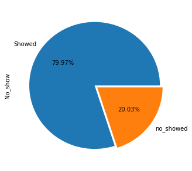

```python
"""
Plot the proportion of No_shows independent variable as a piechart.
Extra parameters are passed to ensure the pie chart is a square,
format the decimal and pop out the second slice for effect.
"""
df.No_show.value_counts().plot.pie(figsize=(5,5), autopct='%.2f%%', explode=(0, .05))
plt.show()
```

```python
# making masks for 2 groups of No_show status
showing_group =df.No_show=='Showed'
noshowing_group=df.No_show=='no_showed'
```

```python
#Getting the counts numbers of the 2 groups
a = df[showing_group].count()
b = df[noshowing_group].count()
print('showing_group counts: \n{}\n noshowing_group counts:\n {}'.format(a,b))
```

```
showing_group counts:
Gender           87341
Age              87341
Neighbourhood    87341
Scholarship      87341
Hypertension     87341
Diabetes         87341
Alcoholism       87341
Handcap          87341
SMS_received     87341
No_show          87341
dtype: int64
 noshowing_group counts:
 Gender           21876
Age              21876
Neighbourhood    21876
Scholarship      21876
Hypertension     21876
Diabetes         21876
Alcoholism       21876
Handcap          21876
SMS_received     21876
No_show          21876
dtype: int64
```

Neerly 20% of all appointments resulted in no_showed. The research questions will attempt to answer what are the human variables for this ratio in terms of gender, age and disease status. Also The research questions will attempt to answer whether this percentage is constant given the social and medical service variables in terms of care grant, hospital and communications.

To answer the research first question we will Analysis 2 groupes of No_show cases 1- according to gender 2- according to age 3- according to Health status

```python
# replacement of Gender column values as folloing: F,M into Female,Male for mor readable plots
replace_Gender = { 'F': 'Female', 'M': 'Male'}
df['Gender'].replace(replace_Gender, inplace = True)
```

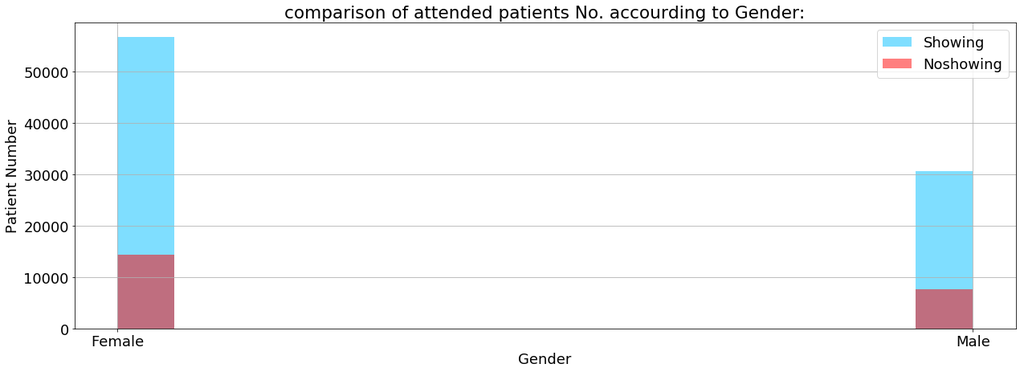

```python
def attend_case(df,column_name,attending,absece):
    plt.rcParams.update({'font.size': 18})
    plt.figure(figsize=[21,7])
    df[column_name][showing_group].hist(alpha=.5, bins=15, color='deepskyblue', label='Showing')
    df[column_name][ noshowing_group].hist(alpha=.5, bins=15, color='red', label='Noshowing')
    plt.legend();
    plt.title('comparison of attended patients No. accourding to {}:'.format(column_name))
    plt.xlabel('{}'.format(column_name))
    plt.ylabel('Patient Number');
attend_case (df,'Gender',showing_group, noshowing_group)
```

```python
# comparing the Counts of Females and males in both showing_group and noshowing_group
a=df.groupby('Gender').No_show.value_counts()

#Comaring the ratio Females and males in both showing_group and noshowing_group
b= df.groupby('Gender').No_show.value_counts(normalize=True).mul(100).round(1).astype(str) + '%'
print(a,'\n\n',b)
```

```
Gender  No_show
Female  Showed       56668
        no_showed    14318
Male    Showed       30673
        no_showed     7558
Name: No_show, dtype: int64

 Gender  No_show
Female  Showed       79.8%
        no_showed    20.2%
Male    Showed       80.2%
        no_showed    19.8%
Name: No_show, dtype: object
```

The number of Females is greater than the number of males in both showing_group and noshowing_group,The number of Females is twice the number of males

But The ratio between Showed and no_showed appointments still nearly 80%:20%

So the effect of the gender variable on appointments attending ( or N0_show varible) is not significant in this analysis

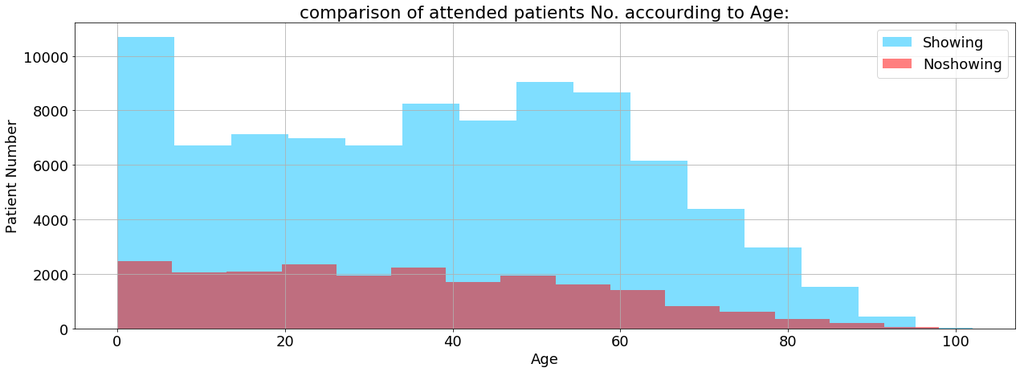

```python
# call plotting function with the 'Age'
attend_case (df,'Age', showing_group, noshowing_group)
```

From the chart, it is clear that the age Category from 0-7 years is the most attended for medical examinations , Followed by the age Categories ranging in age from fifty to over sixty by a few years , While the least age Categories attending to follow-up are the elderly

```python
a= df.groupby('No_show')['Age'].mean()
b= df.groupby('No_show')['Age'].min()
c= df.groupby('No_show')['Age'].max()
print(a,'\n\n', b,'\n\n', c)
```

```
No_show
Showed       37.799487
no_showed    34.281587
Name: Age, dtype: float64

 No_show
Showed       0
no_showed    0
Name: Age, dtype: int64

 No_show
Showed       102
no_showed     98
Name: Age, dtype: int64
```

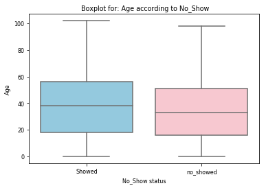

```python
# displaing boxplot to sumrize mean max and min of age according No_show
plt.rcParams.update({'font.size': 8})
my_colors = ['skyblue', 'pink']
sns.set_palette( my_colors )
sns.boxplot(x ='No_show', y= 'Age', data =df);
plt.title(' Boxplot for: Age according to No_Show')
plt.xlabel('No_Show status')
plt.ylabel('Age');
```

From the summarized descriptive statistics,the effect of the Age variable on appointments attending ( or N0_show varible) is significant in this analysis

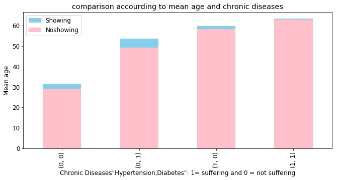

```python
# the relation of No_show with mean age of chronic diseases patients : Hypertension, Diabetes.
# plotting the [showing_group].groupby(['Hypertension' , 'Diabetes']).mean()['Age']
plt.rcParams.update({'font.size': 12})
plt.figure(figsize=[11,5])
df[showing_group].groupby(['Hypertension' , 'Diabetes']).mean()['Age'].plot(kind='bar',color='skyblue',label='Showing')
df[noshowing_group].groupby(['Hypertension' , 'Diabetes']).mean()['Age'].plot(kind='bar',color='pink',label='Noshowing')
plt.legend();
plt.title('comparison accourding to mean age and chronic diseases')
plt.xlabel('Chronic Diseases\"Hypertension,Diabetes\": 1= suffering and 0 = not suffering')
plt.ylabel('Mean age');
```

```python
a=df[showing_group].groupby(['Hypertension','Diabetes']).mean()['Age']
b=df[noshowing_group].groupby(['Hypertension','Diabetes']).mean()['Age']
print(a,'\n\n', b)
```

```
Hypertension  Diabetes
0             0           31.509052
              1           53.634948
1             0           59.729528
              1           63.481446
Name: Age, dtype: float64

 Hypertension  Diabetes
0             0           28.784130
              1           49.171329
1             0           58.352918
              1           62.952889
Name: Age, dtype: float64
```

The average age of attendees the appointments without suffering pressure and diabetes is nearly 31 years. The average age of attendees the appointments whom suffering pressure and diabetes is about 63 years The average age of non attendees the appointments without suffering pressure and diabetes is nearly 28 years. The average age of non attendees the appointments whom suffering pressure and diabetes is about 62 years

From the summarized descriptive statistics,and as showen in the chart: the effect of the mean Age variable accompiend with chronic diseases on appointments attending ( or N0_show varible) is significant in this analysis

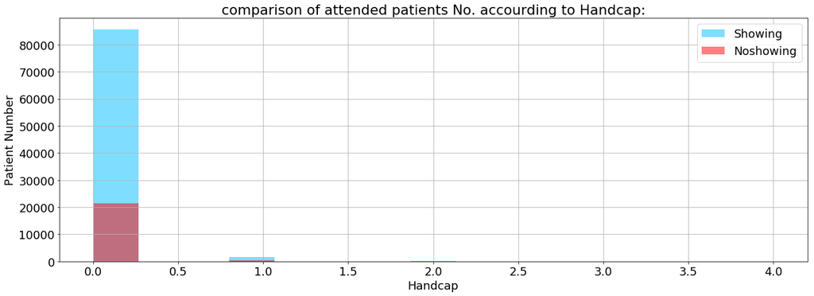

```python
# continue with Handcap and no_show chart:
attend_case (df,'Handcap',showing_group, noshowing_group)
```

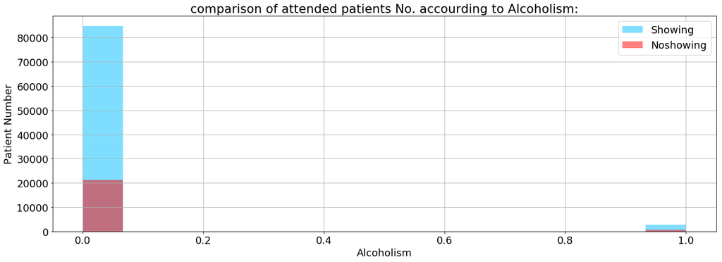

```python
# continue with Alcoholism and no_show chart:
attend_case (df,'Alcoholism',showing_group, noshowing_group)
```

```python
# according Alcoholism and Handcap
# this table of counts the values of these variabls in showing_group
df[showing_group].groupby(['Alcoholism' , 'Handcap']).count()
```

| Alcoholism | Handcap | Gender | Age | Neighbourhood | Scholarship | Hypertension | Diabetes | SMS_received | No_show |
| --- | --- | --- | --- | --- | --- | --- | --- | --- | --- |
| 0 | 0 | 82924 | 82924 | 82924 | 82924 | 82924 | 82924 | 82924 | 82924 |
|  | 1 | 1598 | 1598 | 1598 | 1598 | 1598 | 1598 | 1598 | 1598 |
|  | 2 | 142 | 142 | 142 | 142 | 142 | 142 | 142 | 142 |
|  | 3 | 7 | 7 | 7 | 7 | 7 | 7 | 7 | 7 |
|  | 4 | 2 | 2 | 2 | 2 | 2 | 2 | 2 | 2 |
| 1 | 0 | 2603 | 2603 | 2603 | 2603 | 2603 | 2603 | 2603 | 2603 |
|  | 1 | 62 | 62 | 62 | 62 | 62 | 62 | 62 | 62 |
|  | 2 | 2 | 2 | 2 | 2 | 2 | 2 | 2 | 2 |
|  | 3 | 1 | 1 | 1 | 1 | 1 | 1 | 1 | 1 |

```python
# according Alcoholism and Handcap
# this table of counts the values of these variabls in noshowing_group
df[noshowing_group].groupby(['Alcoholism' , 'Handcap']).count()
```

| Alcoholism | Handcap | Gender | Age | Neighbourhood | Scholarship | Hypertension | Diabetes | SMS_received | No_show |
| --- | --- | --- | --- | --- | --- | --- | --- | --- | --- |
| 0 | 0 | 20828 | 20828 | 20828 | 20828 | 20828 | 20828 | 20828 | 20828 |
|  | 1 | 346 | 346 | 346 | 346 | 346 | 346 | 346 | 346 |
|  | 2 | 35 | 35 | 35 | 35 | 35 | 35 | 35 | 35 |
|  | 3 | 3 | 3 | 3 | 3 | 3 | 3 | 3 | 3 |
|  | 4 | 1 | 1 | 1 | 1 | 1 | 1 | 1 | 1 |
| 1 | 0 | 653 | 653 | 653 | 653 | 653 | 653 | 653 | 653 |
|  | 1 | 8 | 8 | 8 | 8 | 8 | 8 | 8 | 8 |
|  | 2 | 2 | 2 | 2 | 2 | 2 | 2 | 2 | 2 |

There are diffrent values for having Handcap (0,1,2,3,4) There are diffrent values for having Handcap (0,1,2)

```python
df[noshowing_group].groupby(['Alcoholism' , 'Handcap']).mean()['Age']
```

```
Alcoholism  Handcap
0           0          33.650423
            1          45.991329
            2          58.257143
            3          32.666667
            4           9.000000
1           0          46.710567
            1          49.000000
            2          60.000000
Name: Age, dtype: float64
```

The average age of non attendees the appointments without suffering Alcoholism and Handcap is nearly 33 years. The average age of non attendees the appointments whom suffering Alcoholism and not any Handcap type is about 46 years

### Research Question 2

Are social_medical_service variables affected the appointments attending regarding to Financial aid, hospital location , and sms communications?

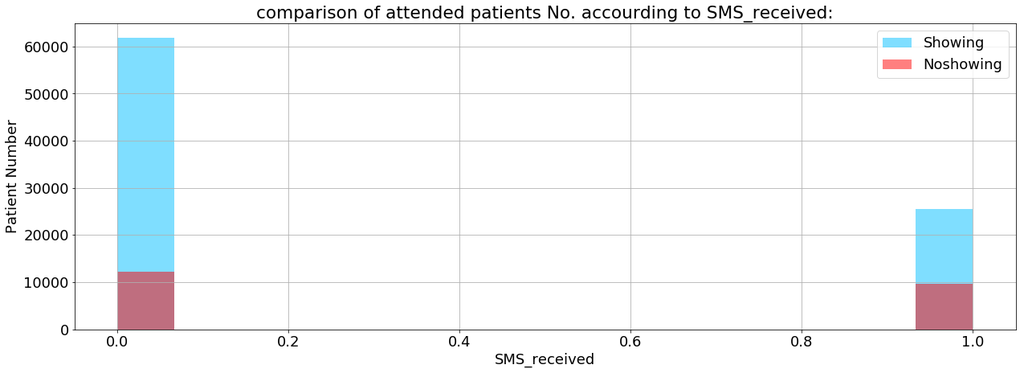

```python
# calling the function to drow chart about SMS_received variable
attend_case (df,'SMS_received',showing_group, noshowing_group)
```

```python
df.groupby('SMS_received').No_show.value_counts()
```

```
SMS_received  No_show
0             Showed       61802
              no_showed    12155
1             Showed       25539
              no_showed     9721
Name: No_show, dtype: int64
```

SMS_received is significant in this analysis

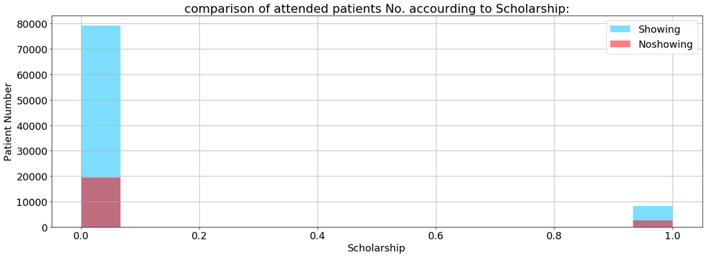

```python
# calling the function to drow chart about SMS_received variable
attend_case (df,'Scholarship',showing_group, noshowing_group)
```

```python
df.groupby('Scholarship').No_show.value_counts()
```

```
Scholarship  No_show
0            Showed       79144
             no_showed    19344
1            Showed        8197
             no_showed     2532
Name: No_show, dtype: int64
```

The number of those who do not receive the Scholarship and attend their medical appointments 79144 and Just looking at their number this is nearly 10 times to The number of those who receive the Scholarship and attend their appointments whom are 8197

So Scholarship is not significant in this analysis

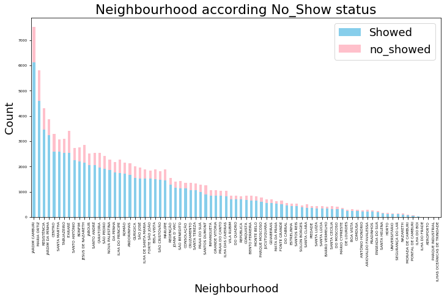

```python
# drawing a chart to Neighbourhood hospitals according to No_show counts
df = pd.crosstab(index=df['Neighbourhood'], columns=df['No_show'])
df_sort = df.sort_values('Showed', ascending = False)
df_sort.plot(kind='bar',figsize = (12,6), fontsize = 6, stacked = True)
plt.xlabel('Neighbourhood')
plt.ylabel('Count')
plt.title('Neighbourhood according No_Show status')
plt.legend();
```

```python
# Continue to explore the data to address your additional research
#   questions. Add more headers as needed if you have more questions to
#   investigate.
```

## Conclusions

> **Tip**: Finally, summarize your findings and the results that have been performed in relation to the question(s) provided at the beginning of the analysis. Summarize the results accurately, and point out where additional research can be done or where additional information could be useful.

> **Tip**: Make sure that you are clear with regards to the limitations of your exploration. You should have at least 1 limitation explained clearly.

> **Tip**: If you haven't done any statistical tests, do not imply any statistical conclusions. And make sure you avoid implying causation from correlation!

> **Tip**: Once you are satisfied with your work here, check over your report to make sure that it is satisfies all the areas of the rubric (found on the project submission page at the end of the lesson). You should also probably remove all of the "Tips" like this one so that the presentation is as polished as possible.

## Submitting your Project

> **Tip**: Before you submit your project, you need to create a .html or .pdf version of this notebook in the workspace here. To do that, run the code cell below. If it worked correctly, you should get a return code of 0, and you should see the generated .html file in the workspace directory (click on the orange Jupyter icon in the upper left).

> **Tip**: Alternatively, you can download this report as .html via the **File** > **Download as** submenu, and then manually upload it into the workspace directory by clicking on the orange Jupyter icon in the upper left, then using the Upload button.

> **Tip**: Once you've done this, you can submit your project by clicking on the "Submit Project" button in the lower right here. This will create and submit a zip file with this .ipynb doc and the .html or .pdf version you created. Congratulations!

```python
from subprocess import call
call(['python', '-m', 'nbconvert', 'Investigate_a_Dataset.ipynb'])
```